# iLykei Lecture Series Machine Learning Neural Networks Workshop 2

Y. Balasanov, L. Nazarov, © iLykei 2016-18

```r
library(neuralnet)
library(data.table)
```

# Credit scoring example

The following example can be found in the [blog](https://www.r-bloggers.com/using-neural-networks-for-credit-scoring-a-simple-example/).  
Data are [available at](https://gist.githubusercontent.com/Bart6114/8675941/raw/ac4cddcc0909c15ceada2d8c6a303206b10796d9/creditset.csv).  
Model is described [here](http://www.ijstm.com/images/short_pdf/1431276484_P_26-31.pdf).

Credit scoring is the practice of analysing a persons background and credit application in order to assess the creditworthiness of the person.  
One can take numerous approaches on analysing this creditworthiness. In the end it basically comes down to first selecting the correct independent variables (e.g. income, age, gender) that lead to a given level of creditworthiness.  
In other words: creditworthiness=f(income, age, gender, …).

The dataset contains information on different clients who received a loan at least 10 years ago.  
The variables income (yearly), age, loan (size in euros) and LTI (the loan to yearly income ratio) are available.  
The goal is to predict, based on the input variables LTI and age, whether or not a default will occur within 10 years.

```r
data <- fread(paste(dataPath,"creditset.csv",sep="/"))
set.seed(1)
data = data[sample(nrow(data))]
head(data)
```

```
##    clientid   income      age       loan        LTI default10yr
## 1:      532 62321.24 45.89028 10649.0721 0.17087387           0
## 2:      744 52510.44 40.27914  1858.3082 0.03538931           0
## 3:     1145 22209.01 22.00626  4096.7837 0.18446494           1
## 4:     1814 57717.61 48.79781  3153.2228 0.05463191           0
## 5:      403 58079.16 18.66303 11540.0458 0.19869513           1
## 6:     1793 36535.32 29.87489   271.7252 0.00743733           0
```

Separate the data into train and test.

```r
nTrain = 0.7*nrow(data)
train <- data[1:nTrain]
test <- data[(nTrain+1):nrow(data)]
dim(train)
```

```
## [1] 1400    6
```

```r
dim(test)
```

```
## [1] 600   6
```

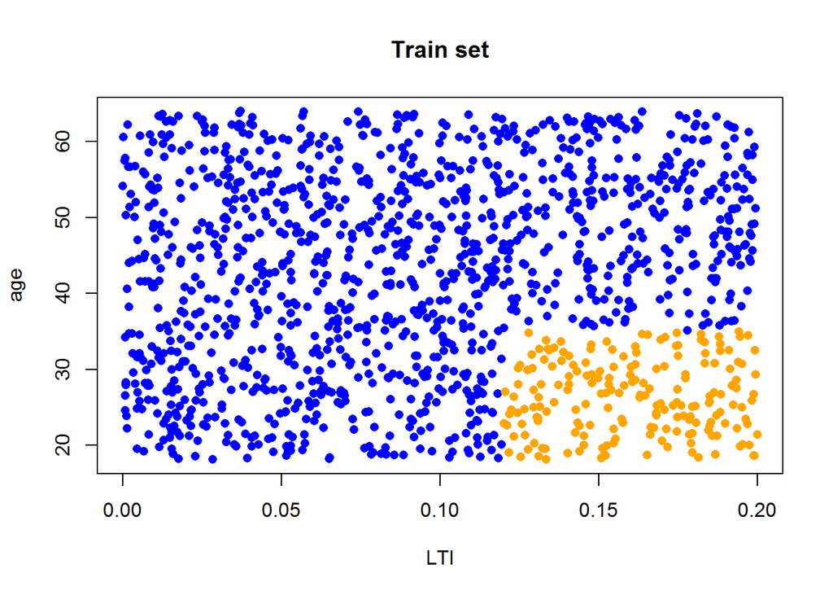

```r
plot(train[,.(LTI,age)],pch=16,col="blue",main="Train set")
points(subset(train[,.(LTI,age)],train$default10yr==1),pch=16,col="orange")
```

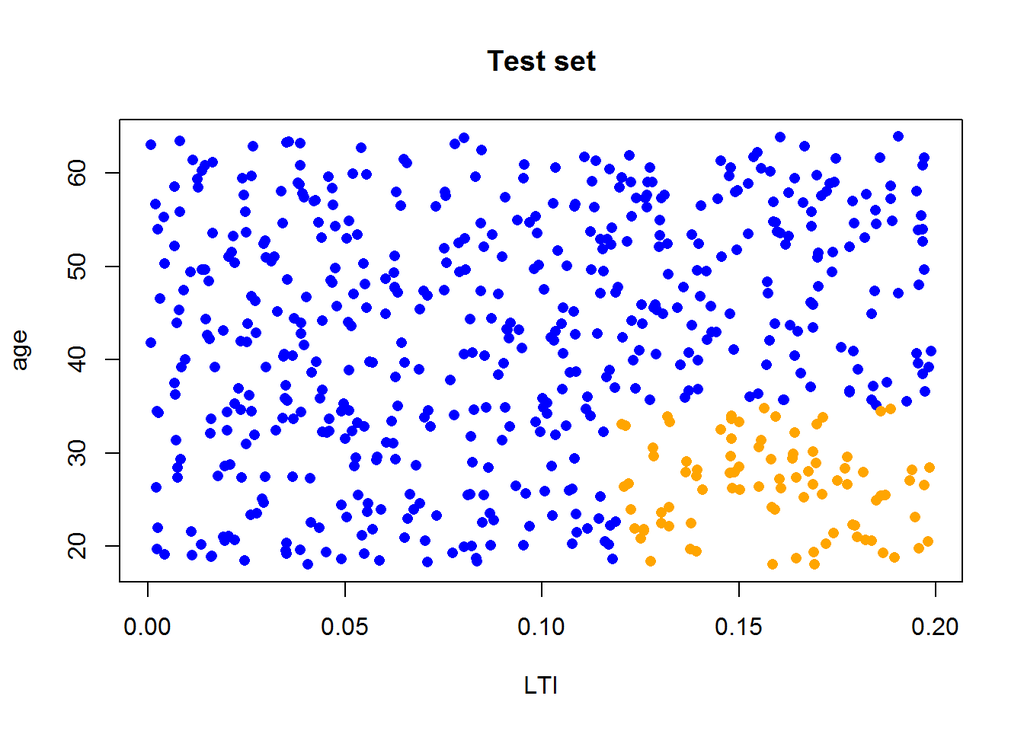

```r
plot(test[,.(LTI,age)],pch=16,col="blue",main="Test set")
points(subset(test[,.(LTI,age)],test$default10yr==1),pch=16,col="orange")
```

Train neural net with one hidden layer including 4 neurons.

```r
set.seed(1)
nnFit <- neuralnet(default10yr ~ LTI + age, train, hidden = 4, lifesign = "minimal",
                   linear.output = FALSE, threshold = 0.1,
                   err.fct = "ce",stepmax = 1e+06)
```

```
## hidden: 4    thresh: 0.1    rep: 1/1    steps:  171222   error: 0.01107  time: 1.97 mins
```

```r
names(nnFit)
```

```
##  [1] "call"                "response"            "covariate"
##  [4] "model.list"          "err.fct"             "act.fct"
##  [7] "linear.output"       "data"                "net.result"
## [10] "weights"             "startweights"        "generalized.weights"
## [13] "result.matrix"
```

```r
nnFit$result.matrix[1] # error
```

```
## [1] 0.01106905678
```

Plot the configuration.

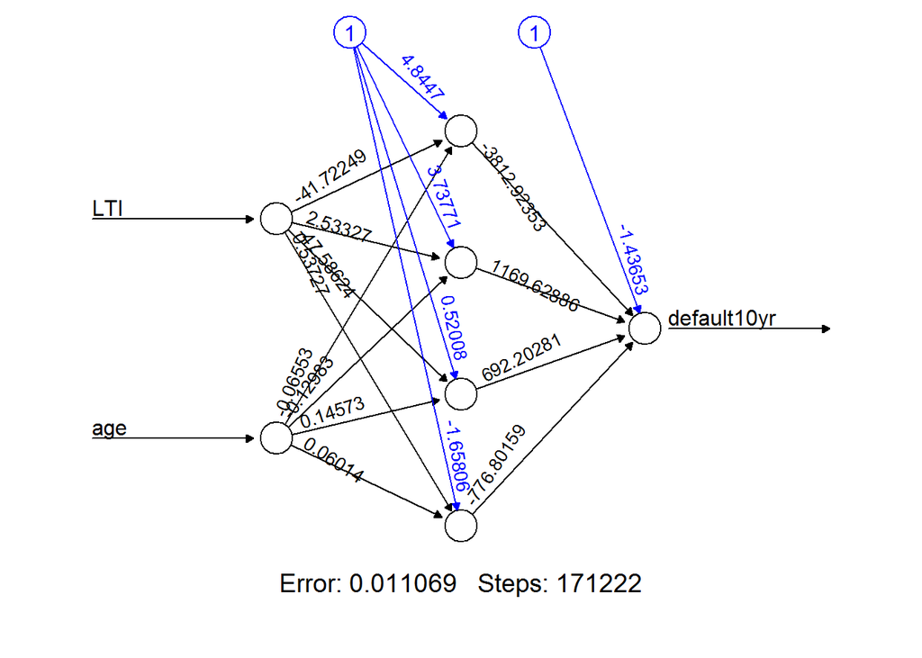

```r
plot(nnFit, rep = "best")
```

Predict the output and measure its accuracy.

```r
nnPred <- round(compute(nnFit, test[,.(LTI,age)])$net.result)
(conf <- table(pred = nnPred, true = test$default10yr))
```

```
##     true
## pred   0   1
##    0 511   2
##    1   0  87
```

```r
(accuracy = (conf[1,1]+conf[2,2])/sum(conf))
```

```
## [1] 0.9966666667
```

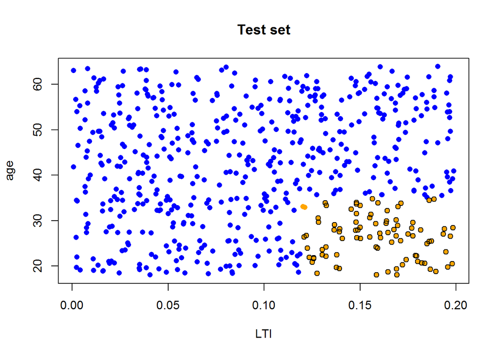

```r
plot(test[,.(LTI,age)],pch=16,col="blue",main="Test set")
points(subset(test[,.(LTI,age)],test$default10yr==1),pch=16,col="orange")
points(subset(test[,.(LTI,age)],nnPred[,1]==1),col="black")
```

Now try to modify network: consider 1 and 2 hidden layers with different numbers of neurons.